# Salarios NBA (CV y Regularización)

Beatriz Quevedo

2020-11-09

Este conjunto de datos se centra en estadísticas avanzadas, que pueden darle una nueva dirección sobre cómo medir el valor de un jugador.

El *objetivo* consiste en utilizar las técnicas de cross validation y regularización para seleccionar el mejor modelo desde un punto de vista predictivo.

# Librerías

```r
library(here)     # comentar
library(tidyverse)
library(janitor)  # clean names
library(skimr)    # beautiful summarize
library(magrittr) # Pipe operators
library(rsample)  # data splotting
library(glmnet)   # implementing regularized regression approaches
library(dplyr)    # basic data manipulation procedures
library(ggplot2)  # plotting
```

# Carga de datos

```r
nba <-  read.csv("../data/nba.csv")
colnames(nba)
```

```
##  [1] "Player"          "Salary"          "NBA_Country"     "NBA_DraftNumber"
##  [5] "Age"             "Tm"              "G"               "MP"
##  [9] "PER"             "TS."             "X3PAr"           "FTr"
## [13] "ORB."            "DRB."            "TRB."            "AST."
## [17] "STL."            "BLK."            "TOV."            "USG."
## [21] "OWS"             "DWS"             "WS"              "WS.48"
## [25] "OBPM"            "DBPM"            "BPM"             "VORP"
```

# Tratamiento de las variables

## Renombre de columnas

```r
nba %<>% clean_names()
colnames(nba)
```

```
##  [1] "player"           "salary"           "nba_country"      "nba_draft_number"
##  [5] "age"              "tm"               "g"                "mp"
##  [9] "per"              "ts"               "x3p_ar"           "f_tr"
## [13] "orb"              "drb"              "trb"              "ast"
## [17] "stl"              "blk"              "tov"              "usg"
## [21] "ows"              "dws"              "ws"               "ws_48"
## [25] "obpm"             "dbpm"             "bpm"              "vorp"
```

## Identificación de filas duplicadas

No hay valores duplicados, por lo que no hace falta eliminar ninguna fila.

```r
nrow(nba[duplicated(nba), ])
```

```
## [1] 0
```

## Identificación de valores nulos

Confirmamos que hay al menos un valor nulo en el DataFrame.

```r
any(is.na(nba))
```

```
## [1] TRUE
```

En concreto, 8. Como no son muchos, se eliminarán.

```r
sum(is.na(nba))
```

```
## [1] 8
```

```r
nba %<>% drop_na()
```

## Eliminación de las variables categóricas del DataFrame

```r
vcategoricas <- c('player', 'nba_country', 'tm')

nba <- nba  %<>% select_at(vars(-vcategoricas))
```

[output not shown]

```r
view(nba)
```

# Separación de la muestra en dos partes

```r
set.seed(91120)
data_split <- initial_split(nba, prob = 0.70, strata = 'salary')
data_train <- training(data_split)
data_test  <- testing(data_split)
```

# Métodos de contracción

Se ajustará un modelo que contiene todos los *p* predictores usando técnicas que restringen o regularizan las estimaciones de coeficientes, o equivalentemente, que reduce las estimaciones de coeficientes hacia cero. Estas técnicas son la regresión de cresta (Ridge), el lazo (Lasso) y la red elástica (Elastic Net).

## Regresión de cresta

Como ya se ha dividido la muestra anteriormente, se crean modelos matriciales y vectores respuesta para el training y el testing, descartando a sy vez el itercepto.

```r
data_train_x <- model.matrix(salary ~ ., data_train)[, -1]
data_train_y <- log(data_train$salary)

data_test_x <- model.matrix(salary ~ ., data_test)[, -1]
data_test_y <- log(data_test$salary)
```

Para saber la dimensión de la matriz:

```r
dim(data_train_x)
```

```
## [1] 365  24
```

Se aplica la regresión de cresta a los datos de la NBA.

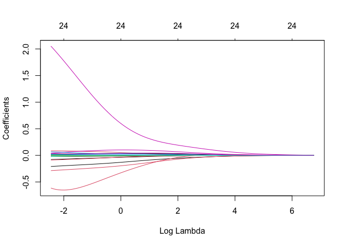

```r
nba_ridge <- glmnet(
  x = data_train_x,
  y = data_train_y,
  alpha = 0
)

plot(nba_ridge, xvar = "lambda")
```

Se realiza una validación cruzada.

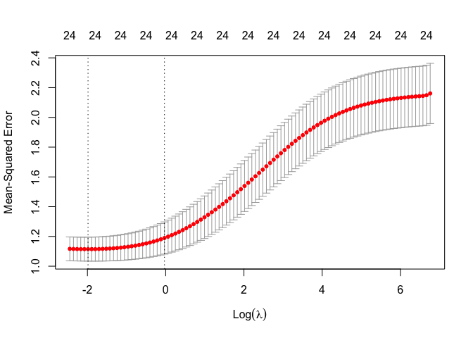

```r
nba_ridge_cv <- cv.glmnet(
  x = data_train_x,
  y = data_train_y,
  alpha = 0
)

plot(nba_ridge_cv)
```

Se observa que el mínimo Error Cuadrático Medio (MSE) es 1.1 aproximadamente.

```r
min(nba_ridge_cv$cvm)
```

```
## [1] 1.114548
```

El lambda para este mínimo MSE es de 0.13 y su logaritmo -1.98.

```r
nba_ridge_cv$lambda.min
```

```
## [1] 0.1374081
```

```r
log(nba_ridge_cv$lambda.min)
```

```
## [1] -1.9848
```

```r
nba_ridge_cv$cvm[nba_ridge_cv$lambda ==nba_ridge_cv$lambda.1se]
```

```
## [1] 1.189448
```

```r
nba_ridge_cv$lambda.1se
```

```
## [1] 0.9693871
```

```r
log(nba_ridge_cv$lambda.1se)
```

```
## [1] -0.03109123
```

Se grafican los datos obtenidos:

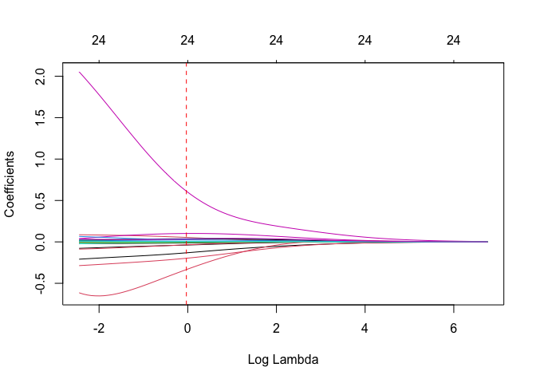

```
## integer(0)
```

```r
plot(nba_ridge, xvar = "lambda") +
abline(v = log(nba_ridge_cv$lambda.1se), col = "red", lty = "dashed")
```

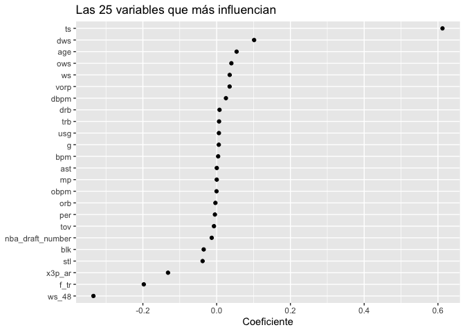

```r
coef(nba_ridge_cv, s = "lambda.1se") %>%
  broom::tidy() %>%
  filter(row != "(Intercept)") %>%
  top_n(25, wt = abs(value)) %>%
  ggplot(aes(value, reorder(row, value))) +
  geom_point() +
  ggtitle("Las 25 variables que más influencian") +
  xlab("Coeficiente") +
  ylab(NULL)
```

## Regresión Lasso

Aplicando esta regresión a los datos del DataFrame con un alpha igual a 1 (forzando algunos de los coeficientes a 0) se obtiene el siguiente gráfico:

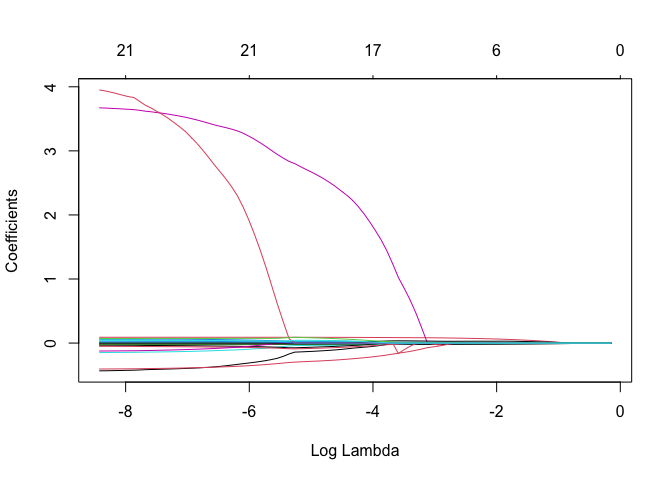

```r
nba_lasso <- glmnet(
  x = data_train_x,
  y = data_train_y,
  alpha = 1
)

plot(nba_lasso, xvar = "lambda")
```

Y realizando la validación cruzada, se obtiene:

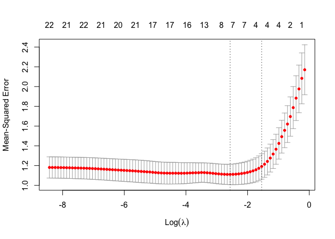

```r
nba_lasso_cv <- cv.glmnet(
  x = data_train_x,
  y = data_train_y,
  alpha = 1
)

plot(nba_lasso_cv)
```

```r
nba_lasso_cv$lambda.min
```

```
## [1] 0.07682227
```

```r
nba_lasso_cv$lambda.1se
```

```
## [1] 0.2137625
```

Graficando (aplicando logaritmos), se obtiene:

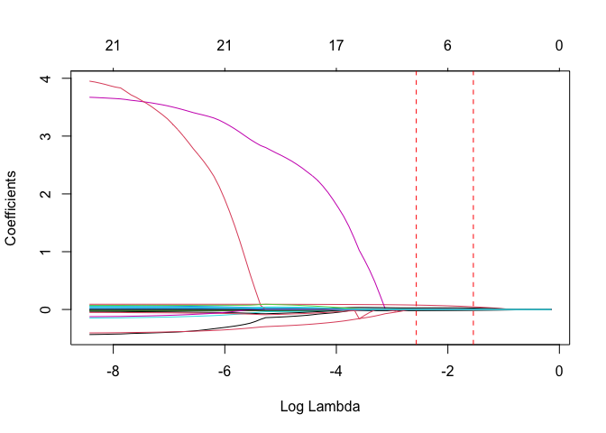

```
## integer(0)
```

```r
plot(nba_lasso, xvar = "lambda") +
abline(v = log(nba_lasso_cv$lambda.min), col = "red", lty = "dashed") +
abline(v = log(nba_lasso_cv$lambda.1se), col = "red", lty = "dashed")
```

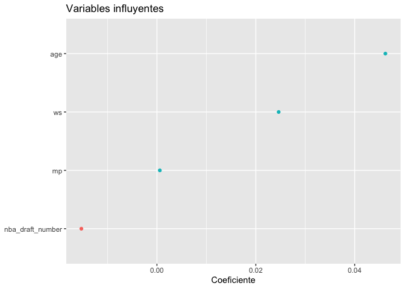

```r
coef(nba_lasso_cv, s = "lambda.1se") %>%
  tidy() %>%
  filter(row != "(Intercept)") %>%
  ggplot(aes(value, reorder(row, value), color = value > 0)) +
  geom_point(show.legend = FALSE) +
  ggtitle("Variables influyentes") +
  xlab("Coeficiente") +
  ylab(NULL)
```

## Red Elástica

Por último, esta técnica de penalización incorporta la selección de variables de Lasso y la contracción de predictores correlacionados de Ridge.

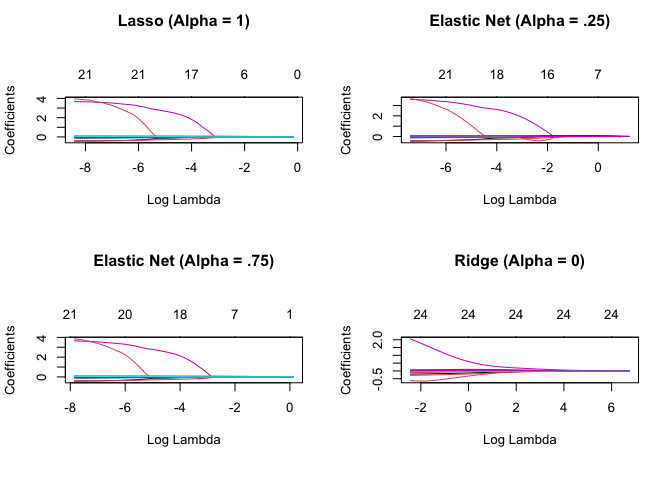

```r
lasso    <- glmnet(data_train_x, data_train_y, alpha = 1.0)
elastic1 <- glmnet(data_train_x, data_train_y, alpha = 0.25)
elastic2 <- glmnet(data_train_x, data_train_y, alpha = 0.75)
ridge    <- glmnet(data_train_x, data_train_y, alpha = 0.0)

par(mfrow = c(2, 2), mar = c(6, 4, 6, 2) + 0.1)
plot(lasso, xvar = "lambda", main = "Lasso (Alpha = 1)\n\n\n")
plot(elastic1, xvar = "lambda", main = "Elastic Net (Alpha = .25)\n\n\n")
plot(elastic2, xvar = "lambda", main = "Elastic Net (Alpha = .75)\n\n\n")
plot(ridge, xvar = "lambda", main = "Ridge (Alpha = 0)\n\n\n")
```

Para elegir el mejor modelo de los 4, se ajustan λ y α.

```r
fold_id <- sample(1:10, size = length(data_train_y), replace=TRUE)

tuning_grid <- tibble::tibble(
  alpha      = seq(0, 1, by = .1),
  mse_min    = NA,
  mse_1se    = NA,
  lambda_min = NA,
  lambda_1se = NA
)
tuning_grid
```

```
## # A tibble: 11 x 5
##    alpha mse_min mse_1se lambda_min lambda_1se
##    <dbl> <lgl>   <lgl>   <lgl>      <lgl>
##  1   0   NA      NA      NA         NA
##  2   0.1 NA      NA      NA         NA
##  3   0.2 NA      NA      NA         NA
##  4   0.3 NA      NA      NA         NA
##  5   0.4 NA      NA      NA         NA
##  6   0.5 NA      NA      NA         NA
##  7   0.6 NA      NA      NA         NA
##  8   0.7 NA      NA      NA         NA
##  9   0.8 NA      NA      NA         NA
## 10   0.9 NA      NA      NA         NA
## 11   1   NA      NA      NA         NA
```

```r
for(i in seq_along(tuning_grid$alpha)) {
  fit <- cv.glmnet(data_train_x, data_train_y, alpha = tuning_grid$alpha[i], foldid = fold_id)
  tuning_grid$mse_min[i]    <- fit$cvm[fit$lambda == fit$lambda.min]
  tuning_grid$mse_1se[i]    <- fit$cvm[fit$lambda == fit$lambda.1se]
  tuning_grid$lambda_min[i] <- fit$lambda.min
  tuning_grid$lambda_1se[i] <- fit$lambda.1se
}

tuning_grid
```

```
## # A tibble: 11 x 5
##    alpha mse_min mse_1se lambda_min lambda_1se
##    <dbl>   <dbl>   <dbl>      <dbl>      <dbl>
##  1   0      1.13    1.23     0.348       1.86
##  2   0.1    1.14    1.23     0.173       1.22
##  3   0.2    1.12    1.20     0.291       0.737
##  4   0.3    1.11    1.21     0.213       0.592
##  5   0.4    1.11    1.19     0.175       0.444
##  6   0.5    1.11    1.20     0.140       0.390
##  7   0.6    1.10    1.19     0.117       0.325
##  8   0.7    1.10    1.18     0.110       0.278
##  9   0.8    1.10    1.19     0.0960      0.267
## 10   0.9    1.10    1.18     0.0854      0.238
## 11   1      1.10    1.18     0.0768      0.214
```

Parece que el modelo con un MSE mínimo menor es el Lasso, que corresponde al alfa = 1.

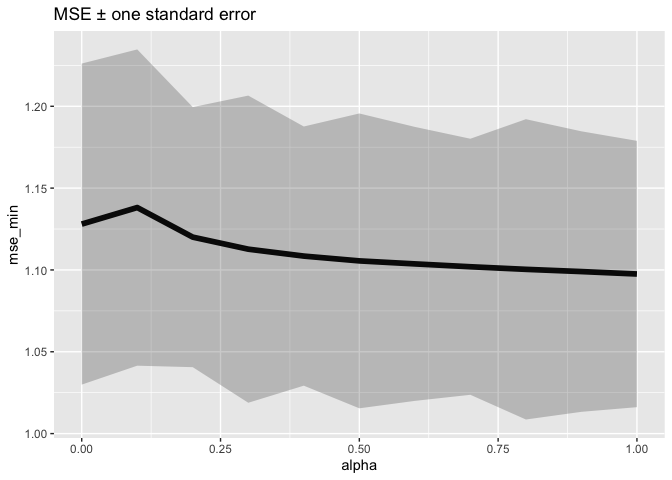

```r
tuning_grid %>%
  mutate(se = mse_1se - mse_min) %>%
  ggplot(aes(alpha, mse_min)) +
  geom_line(size = 2) +
  geom_ribbon(aes(ymax = mse_min + se, ymin = mse_min - se), alpha = .25) +
  ggtitle("MSE ± one standard error")
```

Se comprueba en el gráfico que a medida de aumenta el valor de alfa, se reducen los valores del MSE mínimo. Aún así, el error es mínimo para alfa de 0 a 1, por lo que cualquier modelo sería válido. Por tanto, el modelo que se utilizará es el Lasso porque a diferencia del Ridge no coge todas las variables y es más sencillo.

# Predicción

```r
cv_lasso <- cv.glmnet(data_train_x, data_train_y, alpha = 1.0)
min(cv_lasso$cvm)
```

```
## [1] 1.10223
```

```r
pred <- predict(cv_lasso, s = cv_lasso$lambda.min, data_test_x)
mean((data_test_y - pred)^2)
```

```
## [1] 1.172719
```